# Binomial analysis analysis

anonymous

16/06/2021

## Setup

Load packages:

```r
library(tidyverse) # for data processing
library(brms) # for bayesian models
library(effsize) # for cohen's d
library(patchwork) # for double plots
library(tidybayes) # for half-eye plot
```

Load data:

```r
binoms <- read_csv('../data/binomial_all_frequencies.csv')
```

Quick glance at the structure:

```r
binoms
```

```
## # A tibble: 3,220 × 7
##    binomial                 type      function_word  pair  freq file    register
##    <chr>                    <chr>     <chr>         <dbl> <dbl> <chr>   <chr>
##  1 add and subtract         add_first and               1     0 w_acad… academic
##  2 subtract and add         sub_first and               1     0 w_acad… academic
##  3 add or subtract          add_first or                1     0 w_acad… academic
##  4 subtract or add          sub_first or                1     0 w_acad… academic
##  5 plus and minus           add_first and               2     0 w_acad… academic
##  6 minus and plus           sub_first and               2     0 w_acad… academic
##  7 plus or minus            add_first or                2     2 w_acad… academic
##  8 minus or plus            sub_first or                2     0 w_acad… academic
##  9 addition and subtraction add_first and               3     0 w_acad… academic
## 10 subtraction and addition sub_first and               3     0 w_acad… academic
## # … with 3,210 more rows
```

The pairs are:

```r
pairs <- tibble(pair = 1:7,
                name = c('add and/or subtract', 'plus and/or minus',
                         'addition and/or subtraction', 'more and/or less',
                         'increase and/or decrease', 'many and/or few',
                         'most and/or least'))
```

In this analysis, we are not interested in the difference for and/or, so we’ll average over that:

```r
binoms <- binoms %>%
  group_by(pair, type, file, register) %>%
  summarize(freq = sum(freq))
```

Show:

```r
binoms
```

```
## # A tibble: 1,610 × 5
## # Groups:   pair, type, file [1,610]
##     pair type      file            register  freq
##    <dbl> <chr>     <chr>           <chr>    <dbl>
##  1     1 add_first w_acad_1990.txt academic     0
##  2     1 add_first w_acad_1991.txt academic     0
##  3     1 add_first w_acad_1992.txt academic     1
##  4     1 add_first w_acad_1993.txt academic     0
##  5     1 add_first w_acad_1994.txt academic     3
##  6     1 add_first w_acad_1995.txt academic     0
##  7     1 add_first w_acad_1996.txt academic     0
##  8     1 add_first w_acad_1997.txt academic     2
##  9     1 add_first w_acad_1998.txt academic     1
## 10     1 add_first w_acad_1999.txt academic     0
## # … with 1,600 more rows
```

## Descriptive analysis

Calculate averages:

```r
binoms %>%
  group_by(type) %>%
  summarize(total = sum(freq))
```

```
## # A tibble: 2 × 2
##   type      total
##   <chr>     <dbl>
## 1 add_first  6536
## 2 sub_first    90
```

Calculate averages per pair:

```r
binom_pairs <- binoms %>%
  group_by(pair, type) %>%
  summarize(total = sum(freq))
# Show:

binom_pairs
```

```
## # A tibble: 14 × 3
## # Groups:   pair [7]
##     pair type      total
##    <dbl> <chr>     <dbl>
##  1     1 add_first   107
##  2     1 sub_first     2
##  3     2 add_first   406
##  4     2 sub_first     0
##  5     3 add_first    59
##  6     3 sub_first     1
##  7     4 add_first  5735
##  8     4 sub_first    62
##  9     5 add_first   161
## 10     5 sub_first    12
## 11     6 add_first    10
## 12     6 sub_first     7
## 13     7 add_first    58
## 14     7 sub_first     6
```

Calculate log frequencies:

```r
binom_pairs <- mutate(binom_pairs,
                      log_freq = log10(total + 1))
```

Calculate ratios:

```r
add_first_totals <- binom_pairs[rep(c(TRUE, FALSE), 7), ]$total
add_second_totals <- binom_pairs[rep(c(FALSE, TRUE), 7), ]$total

ratios <- add_first_totals / add_second_totals
ratios <- tibble(pair = binom_pairs[rep(c(TRUE, FALSE), 7), ]$pair,
       ratio = ratios)

left_join(pairs, ratios)
```

```
## # A tibble: 7 × 3
##    pair name                         ratio
##   <dbl> <chr>                        <dbl>
## 1     1 add and/or subtract          53.5
## 2     2 plus and/or minus           Inf
## 3     3 addition and/or subtraction  59
## 4     4 more and/or less             92.5
## 5     5 increase and/or decrease     13.4
## 6     6 many and/or few               1.43
## 7     7 most and/or least             9.67
```

Calculate Cohen’s d:

```r
cohen.d(log_freq ~ type | Subject(pair), data = binom_pairs, paired = TRUE)
```

```
##
## Cohen's d
##
## d estimate: 1.859758 (large)
## 95 percent confidence interval:
##     lower     upper
## 0.4319982 3.2875185
```

Get the labels for annotation:

```r
pairs$annotate_freqs <- filter(binom_pairs, type == 'sub_first')$log_freq

pairs
```

```
## # A tibble: 7 × 3
##    pair name                        annotate_freqs
##   <int> <chr>                                <dbl>
## 1     1 add and/or subtract                  0.477
## 2     2 plus and/or minus                    0
## 3     3 addition and/or subtraction          0.301
## 4     4 more and/or less                     1.80
## 5     5 increase and/or decrease             1.11
## 6     6 many and/or few                      0.903
## 7     7 most and/or least                    0.845
```

Hand-change the values to plot for the annotate function:

```r
pairs[6, ]$annotate_freqs <- pairs[6, ]$annotate_freqs + 0.033
pairs[7, ]$annotate_freqs <- pairs[7, ]$annotate_freqs - 0.033
```

Make a plot of this:

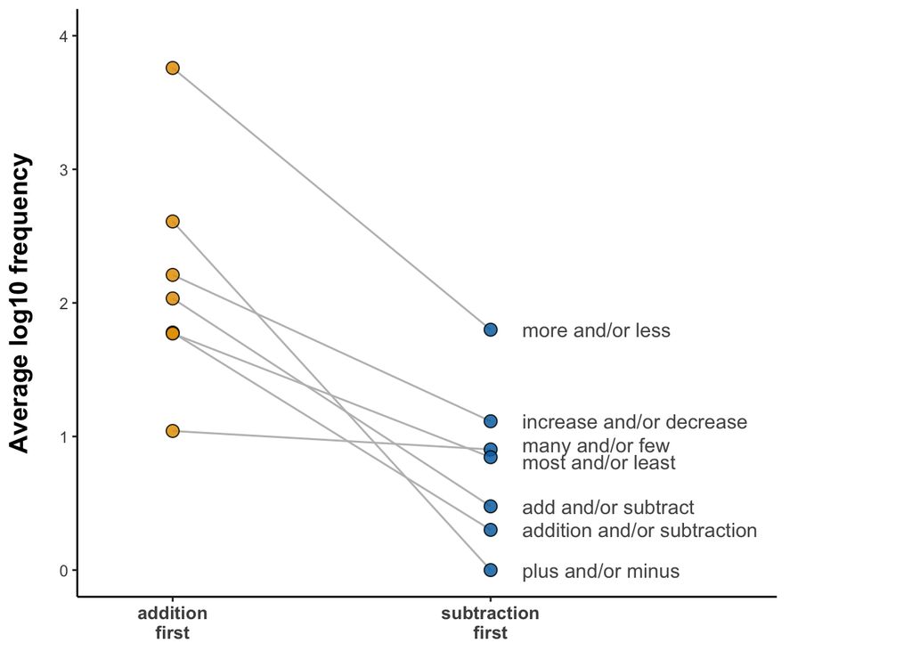

```r
# Define plot and aesthetics:

binom_p <- binom_pairs %>%
  mutate(type = ifelse(type == 'add_first',
                       'addition\nfirst', 'subtraction\nfirst')) %>%
  ggplot(aes(x = type, y = log_freq, fill = type, group = pair))

# Add geoms:

binom_p <- binom_p +
  geom_line(col = 'grey') +
  geom_point(size = 3, shape = 21, alpha = 0.85) +
  annotate(geom = 'text',
           x = rep(2.1, nrow(pairs)),
           y = pairs$annotate_freqs,
           label = pairs$name,
           hjust = 0,
           col = 'grey33')

# Add scales and axes labels:

binom_p <- binom_p +
  scale_y_continuous(breaks = seq(0, 4, 1)) +
  scale_fill_manual(values = c("#E69F00", "#0072B2")) +
  coord_cartesian(xlim = c(1.3, 2.3), ylim = c(0, 4),
                  clip = 'off') +
  xlab(NULL) +
  ylab('Average log10 frequency')

# Add themes:

binom_p <- binom_p +
  theme_classic() +
  theme(legend.position = 'none') +
  theme(axis.title.y = element_text(margin = margin(t = 0, r = 15,
                                                    b = 0, l = 0),
                                    size = 14, face = 'bold'),
        axis.text.x = element_text(face = 'bold', size = 10),
        plot.margin = margin(r = 75, l = 5, b = 5, t = 5))

# Show and save:

binom_p
```

```r
ggsave(plot = binom_p,
       filename = '../figures/pdf/binomial_frequencies.pdf',
       width = 4, height = 4)
ggsave(plot = binom_p,
       filename = '../figures/png/binomial_frequencies.png',
       width = 4, height = 4)
ggsave(plot = binom_p,
       filename = '../figures/tiff/binomial_frequencies.tiff',
       width = 4, height = 4)
```

## Bayesian model

How many are zeros?

```r
sum(binoms$freq == 0) / nrow(binoms)
```

```
## [1] 0.6981366
```

Look at the number of zeros as a function of add/subtract first:

```r
binoms %>%
  mutate(is_zero = freq == 0) %>%
  group_by(type) %>%
  summarize(zeros = sum(is_zero)) %>%
  mutate(prop = zeros / sum(zeros),
         prop = round(prop, 2))
```

```
## # A tibble: 2 × 3
##   type      zeros  prop
##   <chr>     <int> <dbl>
## 1 add_first   389  0.35
## 2 sub_first   735  0.65
```

Make `sub_first` the reference level:

```r
binoms <- mutate(binoms,
                 type = factor(type,
                               levels = c('sub_first', 'add_first')))
```

Weakly informative prior:

```r
weak_prior <- prior(normal(0, 2), class = 'b')
```

Model this with a negative binomial regression model:

```r
# binom_mdl <- brm(bf(freq ~ 1 + type +
#                       (1 + type|pair) + (1 + type|file) + (1 + type|register),
#                     zi ~ 1),
#                  data = binoms,
#
#                  prior = weak_prior,
#
#                  family = zero_inflated_negbinomial('log'),
#
#                  # MCMC settings:
#
#                  seed = 666, chains = 4, cores = 4,
#                  warmup = 4000, iter = 6000,
#                  control = list(adapt_delta = 0.99))
```

Alternatively, load the model (to save time):

```r
load('../models/binomial_model.RData')
```

Save the model:

```r
# save(binom_mdl, file = '../models/binomial_model.RData')
```

Check the model:

```r
binom_mdl
```

```
##  Family: zero_inflated_negbinomial
##   Links: mu = log; shape = identity; zi = logit
## Formula: freq ~ 1 + type + (1 + type | pair) + (1 + type | file) + (1 + type | register)
##          zi ~ 1
##    Data: binoms (Number of observations: 1610)
##   Draws: 4 chains, each with iter = 6000; warmup = 4000; thin = 1;
##          total post-warmup draws = 8000
##
## Group-Level Effects:
## ~file (Number of levels: 115)
##                              Estimate Est.Error l-95% CI u-95% CI Rhat Bulk_ESS
## sd(Intercept)                    0.11      0.11     0.00     0.44 1.00     2147
## sd(typeadd_first)                0.11      0.12     0.00     0.46 1.00     2266
## cor(Intercept,typeadd_first)    -0.40      0.58    -1.00     0.87 1.00     3374
##                              Tail_ESS
## sd(Intercept)                    3172
## sd(typeadd_first)                3217
## cor(Intercept,typeadd_first)     4655
##
## ~pair (Number of levels: 7)
##                              Estimate Est.Error l-95% CI u-95% CI Rhat Bulk_ESS
## sd(Intercept)                    1.88      0.67     0.96     3.58 1.00     3316
## sd(typeadd_first)                2.35      0.85     1.19     4.42 1.00     3127
## cor(Intercept,typeadd_first)    -0.18      0.37    -0.78     0.58 1.00     2982
##                              Tail_ESS
## sd(Intercept)                    5574
## sd(typeadd_first)                4770
## cor(Intercept,typeadd_first)     4549
##
## ~register (Number of levels: 5)
##                              Estimate Est.Error l-95% CI u-95% CI Rhat Bulk_ESS
## sd(Intercept)                    0.82      0.45     0.33     1.96 1.00     3478
## sd(typeadd_first)                0.32      0.28     0.01     1.04 1.00     3222
## cor(Intercept,typeadd_first)    -0.46      0.49    -0.99     0.73 1.00     6636
##                              Tail_ESS
## sd(Intercept)                    4774
## sd(typeadd_first)                4275
## cor(Intercept,typeadd_first)     5501
##
## Population-Level Effects:
##               Estimate Est.Error l-95% CI u-95% CI Rhat Bulk_ESS Tail_ESS
## Intercept        -3.25      0.82    -4.89    -1.63 1.00     2473     3968
## zi_Intercept     -5.07      1.31    -8.22    -3.23 1.00     7552     3777
## typeadd_first     2.87      0.89     0.88     4.48 1.00     2747     3398
##
## Family Specific Parameters:
##       Estimate Est.Error l-95% CI u-95% CI Rhat Bulk_ESS Tail_ESS
## shape     2.50      0.33     1.93     3.23 1.00    14726     5778
##
## Draws were sampled using sampling(NUTS). For each parameter, Bulk_ESS
## and Tail_ESS are effective sample size measures, and Rhat is the potential
## scale reduction factor on split chains (at convergence, Rhat = 1).
```

Perform posterior predictive checks (with empirical cumulative distribution function):

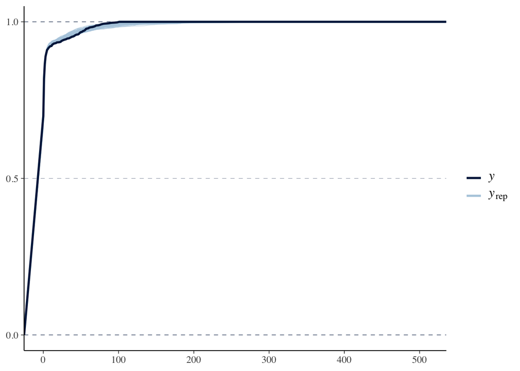

```r
pp_check(binom_mdl,
         ndraws = 100,
         type = 'ecdf_overlay')
```

Perform a test of the posterior probability of the effect being above/below zero.

```r
hypothesis(binom_mdl, 'typeadd_first < 0')
```

```
## Hypothesis Tests for class b:
##            Hypothesis Estimate Est.Error CI.Lower CI.Upper Evid.Ratio Post.Prob
## 1 (typeadd_first) < 0     2.87      0.89     1.32     4.23       0.01         0
##   Star
## 1
## ---
## 'CI': 90%-CI for one-sided and 95%-CI for two-sided hypotheses.
## '*': For one-sided hypotheses, the posterior probability exceeds 95%;
## for two-sided hypotheses, the value tested against lies outside the 95%-CI.
## Posterior probabilities of point hypotheses assume equal prior probabilities.
```

```r
hypothesis(binom_mdl, 'typeadd_first > 0')
```

```
## Hypothesis Tests for class b:
##            Hypothesis Estimate Est.Error CI.Lower CI.Upper Evid.Ratio Post.Prob
## 1 (typeadd_first) > 0     2.87      0.89     1.32     4.23        199         1
##   Star
## 1    *
## ---
## 'CI': 90%-CI for one-sided and 95%-CI for two-sided hypotheses.
## '*': For one-sided hypotheses, the posterior probability exceeds 95%;
## for two-sided hypotheses, the value tested against lies outside the 95%-CI.
## Posterior probabilities of point hypotheses assume equal prior probabilities.
```

Do this by hand by extracting posterior samples:

```r
binom_samples <- posterior_samples(binom_mdl)
```

Plot the posterior:

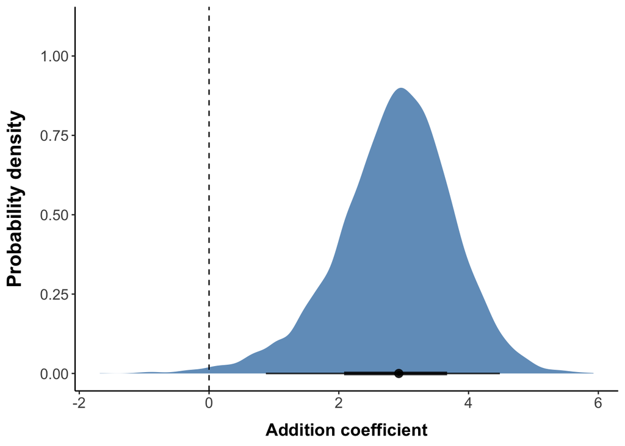

```r
post_p <- binom_samples %>%
  ggplot(aes(x = b_typeadd_first)) +
  stat_halfeye(fill = 'steelblue', alpha = 0.8) +
  geom_vline(xintercept = 0, linetype = 'dashed')

post_p <- post_p +
  xlab('Addition coefficient') +
  ylab('Probability density') +
  coord_cartesian(y = c(0, 1.1), clip = 'off') +
  scale_y_continuous(breaks = seq(0, 1, 0.25))

post_p <- post_p +
  theme_classic() +
  theme(axis.text.x = element_text(size = 12),
        axis.text.y = element_text(size = 12),
        axis.title.x = element_text(face = 'bold', size = 14,
                                    margin = margin(t = 10)),
        axis.title.y = element_text(face = 'bold', size = 16,
                                    margin = margin(r = 12)))

post_p
```

Put the raw frequencies and the posterior into a double plot:

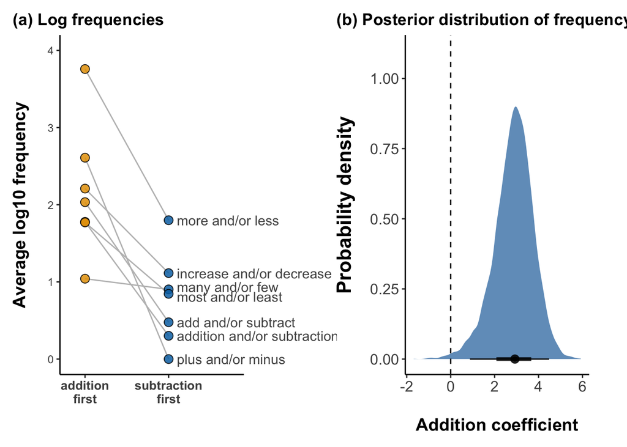

```r
# Tweak plots for double plotting:

binom_p <- binom_p +
  ggtitle('(a) Log frequencies') +
  theme(plot.title = element_text(face = 'bold'),
        plot.title.position = 'plot')

post_p <- post_p +
  ggtitle('(b) Posterior distribution of frequency difference') +
  theme(plot.title = element_text(face = 'bold'),
        plot.margin = margin(r = 25),
        plot.title.position = 'plot')

# Merge:

both_p <- binom_p + post_p

# Show and save:

both_p
```

```r
ggsave(filename = '../figures/pdf/binomial_double_plot.pdf',
       width = 10, height = 4.5)
ggsave(filename = '../figures/png/binomial_double_plot.png',
       width = 10, height = 4.5)
ggsave(filename = '../figures/tiff/binomial_double_plot.tiff',
       width = 10, height = 4.5)
```